# Modelo Baseline de Pronóstico - Equipo M1-2

Author

Esteban Vega Campos, Owen David Loza, Mariana Izquierdo Preciado y Jocelyn Jiménez Buenrostro

```r
library(fpp3)
mi_serie <- aus_retail |>
  filter(`Series ID` == "A3349401C")

mi_serie
```

```
# A tsibble: 441 x 5 [1M]
# Key:       State, Industry [1]
   State           Industry                        `Series ID`    Month Turnover
   <chr>           <chr>                           <chr>          <mth>    <dbl>
 1 New South Wales Pharmaceutical, cosmetic and t… A3349401C   1982 Apr     43
 2 New South Wales Pharmaceutical, cosmetic and t… A3349401C   1982 May     45.3
 3 New South Wales Pharmaceutical, cosmetic and t… A3349401C   1982 Jun     43.7
 4 New South Wales Pharmaceutical, cosmetic and t… A3349401C   1982 Jul     46.5
 5 New South Wales Pharmaceutical, cosmetic and t… A3349401C   1982 Aug     44.8
 6 New South Wales Pharmaceutical, cosmetic and t… A3349401C   1982 Sep     43.9
 7 New South Wales Pharmaceutical, cosmetic and t… A3349401C   1982 Oct     45.6
 8 New South Wales Pharmaceutical, cosmetic and t… A3349401C   1982 Nov     45.3
 9 New South Wales Pharmaceutical, cosmetic and t… A3349401C   1982 Dec     55
10 New South Wales Pharmaceutical, cosmetic and t… A3349401C   1983 Jan     47.4
# ℹ 431 more rows
```

## Análisis exploratorio

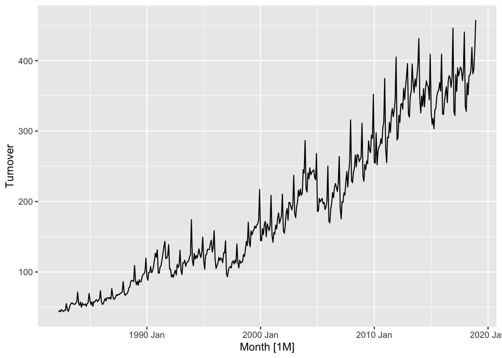

```r
mi_serie |> autoplot(Turnover)
```

Como se puede observar, la serie muestra una tendencia creciente notoria a lo largo del tiempo (1982-2018). De igual forma, se presenta una estacionalidad anual con picos recurrentes que coinciden con temporadas altas. Por el otro lado, la amplitud de la varianza aumenta conforme crece el nivel de la serie, lo cual nos dice que es necesario estabilizar la varianza.

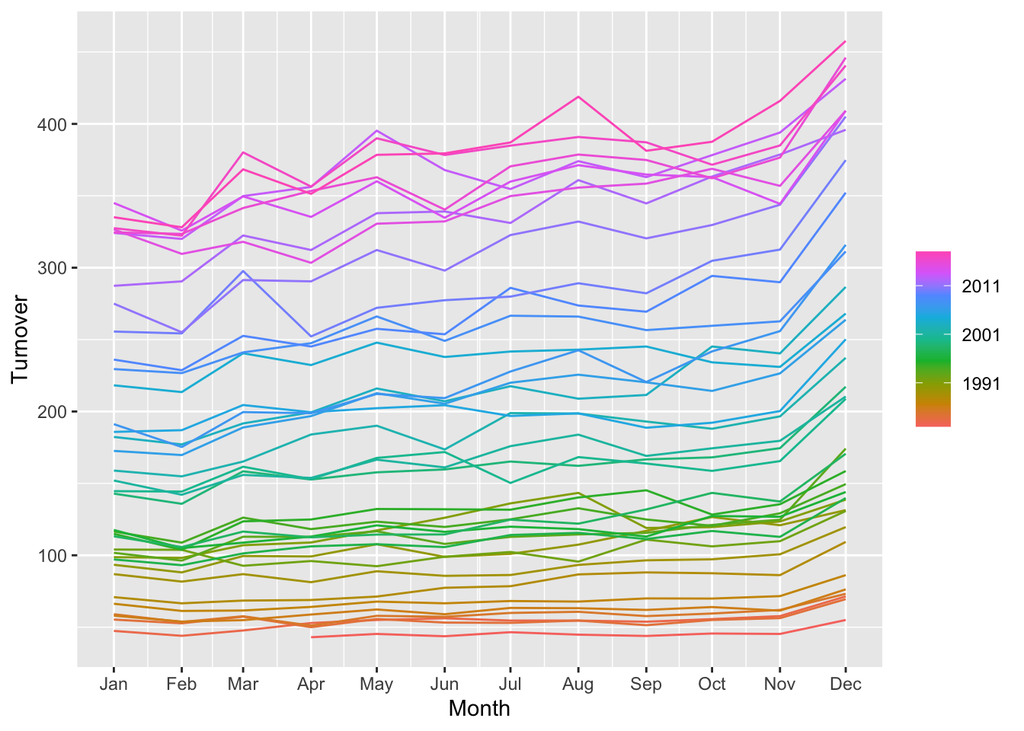

```r
mi_serie |> gg_season(Turnover)
```

El gráfico estacional nos confirma que diciembre es el mes con mayor turnover en todos los años de la serie, seguido de una caída en enero y febrero. Este suceso se repite de forma estable año con año, aunque la magnitud de estos picos crece junto con el nivel de la serie.

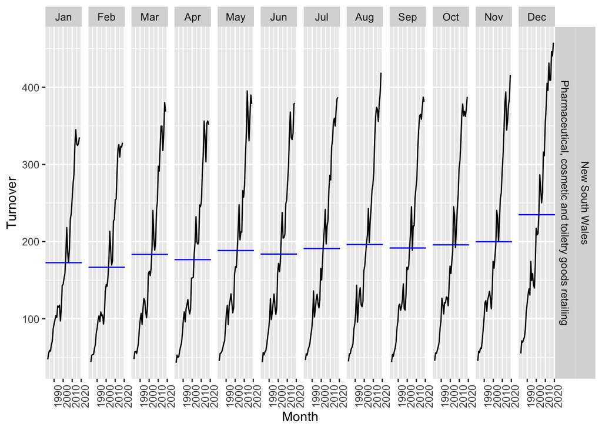

```r
mi_serie |> gg_subseries(Turnover)
```

El gráfico de subseries nos confirma que el patrón estacional es estable a lo largo del tiempo. Cada mes mantiene una tendencia de crecimiento similar y diciembre se mantiene como el mes con un mayor turnover promedio.

> **Conclusión EDA:** la serie presenta tendencia creciente y estacionalidad anual, con una varianza que aumenta junto con el nivel. Esto indica que se necesita estabilizar la varianza antes de modelar.

## Estabilización de varianza

```r
lambda <- mi_serie |>
  features(Turnover, features = guerrero) |>
  pull(lambda_guerrero)

lambda
```

```
[1] 0.08810527
```

Se estimó el parámetro de Box-Cox y nos dio un resultado de (0.088). Este valor es cercano a 0, lo cual confirma que se requiere estabilizar la varianza, con una transformación similar a una escala logarítmica.

## Descomposición STL

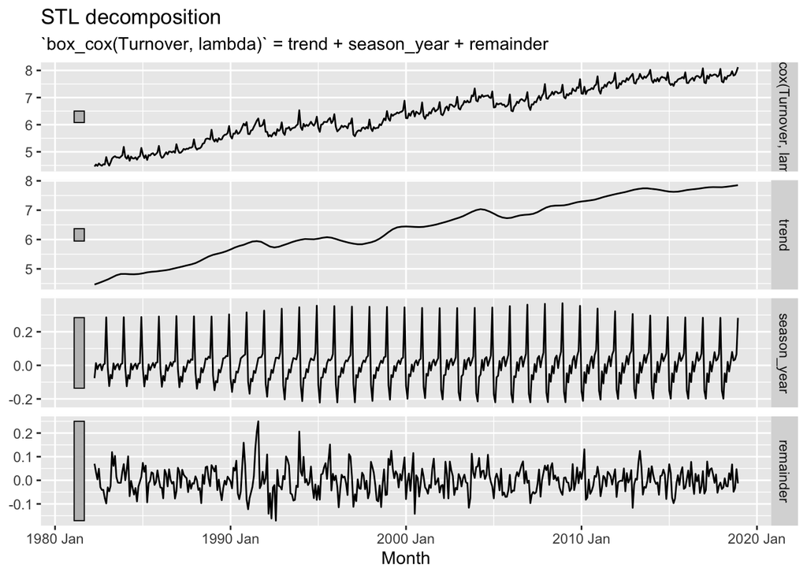

```r
mi_serie |>
  model(STL(box_cox(Turnover, lambda))) |>
  components() |>
  autoplot()
```

## División train / test

La serie termina en diciembre de 2018, así que el conjunto de prueba abarca los últimos 24 meses observados: enero 2017 – diciembre 2018.

```r
h_test <- 24
corte  <- max(mi_serie$Month) - h_test

serie_train <- mi_serie |> filter(Month <= corte)
serie_test  <- mi_serie |> filter(Month >  corte)

c(train = nrow(serie_train), test = nrow(serie_test))
```

```
train  test
  417    24
```

```r
range(serie_train$Month)
```

```
<yearmonth[2]>
[1] "1982 Apr" "2016 Dec"
```

```r
range(serie_test$Month)
```

```
<yearmonth[2]>
[1] "2017 Jan" "2018 Dec"
```

## Modelo baseline

El parámetro de Box-Cox se reestima usando **únicamente el conjunto de entrenamiento**. El valor resultante (0.061) difiere del estimado sobre la serie completa (0.088), aunque ambos se ubican cerca de cero, por lo que en la práctica se trata de una transformación aproximadamente logarítmica en los dos casos. Estimarlo con todos los datos implicaría usar información del conjunto de prueba para calibrar el modelo, lo cual contamina la evaluación posterior.

```r
lambda_train <- serie_train |>
  features(Turnover, features = guerrero) |>
  pull(lambda_guerrero)

c(completa = lambda, train = lambda_train)
```

```
  completa      train
0.08810527 0.06123414
```

```r
fit_train <- serie_train |>
  model(
    baseline = decomposition_model(
      STL(box_cox(Turnover, lambda_train)),
      RW(season_adjust ~ drift()),
      SNAIVE(season_year)
    )
  )

fit_train
```

```
# A mable: 1 x 3
# Key:     State, Industry [1]
  State           Industry                                              baseline
  <chr>           <chr>                                                  <model>
1 New South Wales Pharmaceutical, cosmetic and toilet… <STL decomposition model>
```

```r
fit_compare <- serie_train |>
  model(
    baseline = decomposition_model(
      STL(box_cox(Turnover, lambda_train)),
      RW(season_adjust ~ drift()),
      SNAIVE(season_year)
    ),
    snaive_puro = SNAIVE(Turnover)
  )

fit_compare
```

```
# A mable: 1 x 4
# Key:     State, Industry [1]
  State           Industry                                  baseline snaive_puro
  <chr>           <chr>                                      <model>     <model>
1 New South Wales Pharmaceutical, cosmeti… <STL decomposition model>    <SNAIVE>
```

El modelo baseline descompone la serie transformada con STL y pronostica cada componente por separado: la serie ajustada estacionalmente con una caminata aleatoria con deriva, que captura la tendencia creciente, y el componente estacional con SNAIVE, que repite el patrón del año anterior. Al final `decomposition_model()` recompone ambos pronósticos y revierte la transformación Box-Cox, de modo que el resultado queda en la escala original de `Turnover`.

Para el reentrenamiento con la serie completa se debe usar `lambda` (estimado sobre toda la serie en la sección de estabilización de varianza), no `lambda_train`, ya que en esa etapa ya no existe un conjunto de prueba que proteger.

## Evaluación del modelo

Se evalúa el modelo baseline con los 24 meses reservados para prueba, de enero de 2017 a diciembre de 2018. El modelo se mantiene ajustado con los 417 datos de entrenamiento, que terminan en diciembre de 2016. De esta manera, se evalúa su capacidad para pronosticar observaciones que no se utilizaron para estimarlo.

### Exactitud de los pronósticos

```r
# Pronosticar los meses reservados para prueba.
fc_test <- fit_compare |> forecast(new_data = serie_test)

# mi_serie incluye el entrenamiento necesario para calcular la escala de MASE.
# Los errores se calculan en las fechas de fc_test: enero 2017 - diciembre 2018.
metricas_test <- fc_test |>
  accuracy(mi_serie) |>
  select(.model, .type, MASE, MAE, RMSE)

mase_baseline <- metricas_test |> filter(.model == "baseline") |> pull(MASE)
mae_baseline  <- metricas_test |> filter(.model == "baseline") |> pull(MAE)
rmse_baseline <- metricas_test |> filter(.model == "baseline") |> pull(RMSE)


knitr::kable(
  metricas_test,
  digits = 3,
  col.names = c("Modelo", "Conjunto", "MASE", "MAE", "RMSE")
)
```

| Modelo | Conjunto | MASE | MAE | RMSE |
| --- | --- | --- | --- | --- |
| baseline | Test | 1.472 | 24.798 | 28.633 |
| snaive_puro | Test | 1.018 | 17.142 | 21.687 |

El **MASE es 1.472**. En esta serie mensual, la escala corresponde al error absoluto medio del método naïve estacional en el entrenamiento: utilizar el valor del mismo mes del año anterior como pronóstico. Por tanto, el error absoluto medio del baseline en prueba equivale a aproximadamente 1.47 veces esa referencia, es decir, es 47.2% mayor.

Se comparó el modelo baseline (descomposición STL + RW con deriva + SNAIVE) contra un `SNAIVE()` puro sobre el mismo conjunto de prueba. El SNAIVE puro obtuvo un MASE de 1.018, MAE de 17.142 y RMSE de 21.687, superando al modelo baseline en las tres métricas (MASE 1.472, MAE 24.798, RMSE 28.633). Esto indica que, para esta serie en particular, el componente de deriva (drift) del modelo baseline introduce más error del que corrige, y que un pronóstico simple basado únicamente en el patrón estacional del año anterior es más preciso en el horizonte de prueba evaluado.

Como métricas complementarias se reportan **MAE** y **RMSE**. El MAE es 24.798 millones de dólares australianos e indica cuánto se alejan los pronósticos de los valores observados, en promedio y en términos absolutos. El RMSE es 28.633 millones de dólares australianos y da mayor peso a los errores grandes. Se incluyen porque expresan el tamaño del error en las unidades originales de `Turnover`.

### Diagnóstico de residuos

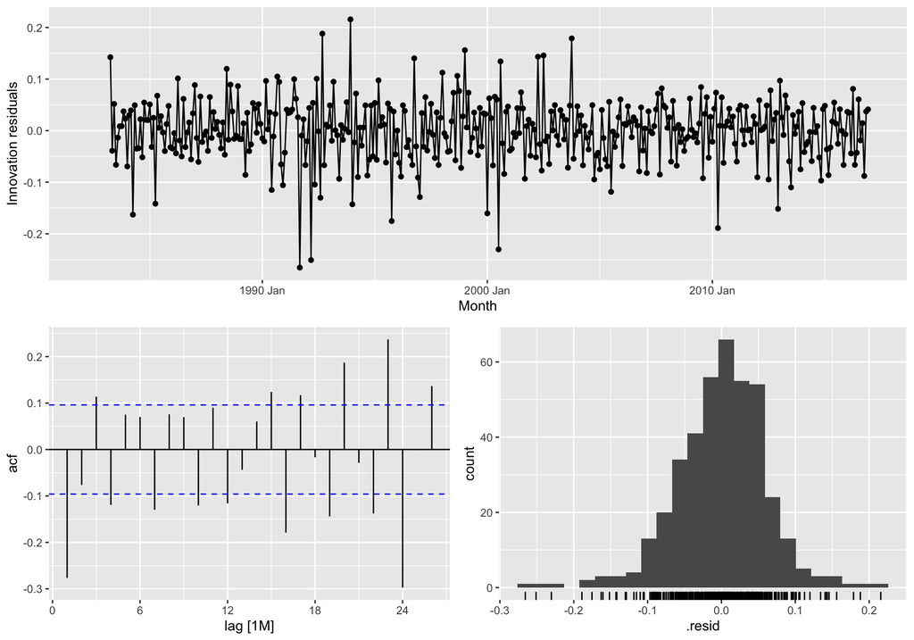

```r
fit_train |>
  select(baseline) |>
  gg_tsresiduals()
```

Se revisan los residuos de innovación del modelo ajustado, en la escala transformada por Box-Cox. Estos residuos corresponden al entrenamiento, mientras que las métricas anteriores corresponden al conjunto de prueba. Hay 405 residuos disponibles; las 12 observaciones iniciales no tienen residuos debido al rezago anual del componente estacional.

- **Serie de residuos:** los valores oscilan alrededor de cero, con una media cercana a -0.000099. También se observan valores extremos, por lo que estar centrados en cero no basta para considerar adecuado el diagnóstico.
- **ACF:** varias barras exceden las bandas de referencia, especialmente en los rezagos 1, 23 y 24. Esto sugiere dependencia temporal que el modelo no ha capturado completamente y se contrasta con Ljung-Box.
- **Histograma:** la mayor parte de los residuos se concentra cerca de cero, con observaciones extremas en ambas colas. Esta inspección visual por sí sola no permite asegurar normalidad.

### Prueba de Ljung-Box

Se contrasta la hipótesis nula de ausencia de autocorrelación en los primeros 24 rezagos. Se eligen 24 porque los datos son mensuales y equivalen a dos ciclos anuales. Se utiliza un nivel de significancia de 5%.

```r
prueba_lb <- fit_train |>
  select(baseline) |>
  augment() |>
  features(.innov, ljung_box, lag = 24)

# Mostrar los valores p muy pequeños sin reportarlos como exactamente cero.
tabla_lb <- prueba_lb |>
  transmute(
    Modelo = .model,
    `Estadístico Ljung-Box` = round(lb_stat, 3),
    `Valor p` = if_else(
      lb_pvalue < 0.001,
      "< 0.001",
      formatC(lb_pvalue, format = "f", digits = 3)
    )
  )

knitr::kable(tabla_lb)
```

| Modelo | Estadístico Ljung-Box | Valor p |
| --- | --- | --- |
| baseline | 198.732 | < 0.001 |

El estadístico de Ljung-Box es **198.732** y el **valor p es menor que 0.001**. Como es menor que 0.05, se rechaza la hipótesis nula. Hay evidencia de autocorrelación en los residuos, lo que coincide con los patrones observados en la ACF. En consecuencia, los residuos no son compatibles con ruido blanco en este diagnóstico.

### Conclusión de la evaluación

El baseline presenta un MAE de aproximadamente 24.798 millones de dólares australianos y un MASE de 1.472 en el conjunto de prueba, desempeño inferior al del SNAIVE puro evaluado como comparación (MASE 1.018, MAE 17.142). Además, la ACF y la prueba de Ljung-Box muestran dependencia temporal en los residuos. Aunque su media es cercana a cero, el modelo todavía deja estructura temporal sin explicar. Estos resultados permiten utilizarlo como punto de partida tal como lo requiere el proyecto, documentando abiertamente sus limitaciones frente a un benchmark más simple.

## Forecast final

### Reentrenamiento de la serie completa

```r
fit_full <- mi_serie |>
  model(
    baseline = decomposition_model(
      STL(box_cox(Turnover, lambda)),
      RW(season_adjust ~ drift()),
      SNAIVE(season_year)
    )
  )

fit_full
```

```
# A mable: 1 x 3
# Key:     State, Industry [1]
  State           Industry                                              baseline
  <chr>           <chr>                                                  <model>
1 New South Wales Pharmaceutical, cosmetic and toilet… <STL decomposition model>
```

### Pronóstico a 24 meses

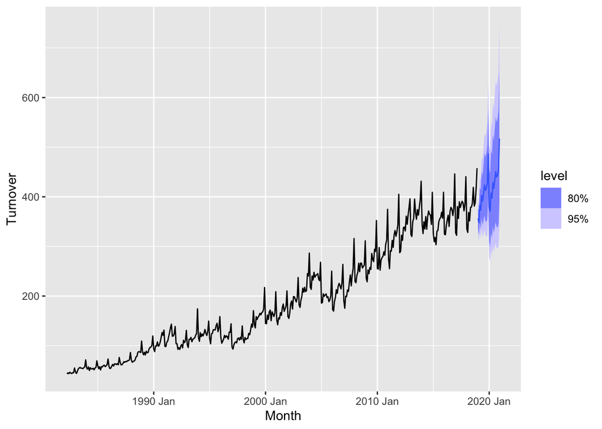

```r
fc_final <- fit_full |> forecast(h = "24 months")

fc_final |> autoplot(mi_serie)
```

El pronóstico proyecta el turnover de la serie NSW de farmacia/cosmética/tocador para los 24 meses siguientes al final de la serie observada. La proyección conserva la tendencia creciente y el patrón estacional capturado por el modelo decomposition_model(), con bandas de confianza del 80% y 95% que se amplían conforme aumenta el horizonte de pronóstico — comportamiento esperado, ya que la incertidumbre crece entre más lejos se proyecta.

### Limitaciones

Este modelo es un baseline y como tal tiene limitaciones documentadas en la Fase 3: un MASE de 1.472 (peor que la referencia naïve estacional) y autocorrelación residual significativa (Ljung-Box, p < 0.001). Esto sugiere que el modelo no captura toda la estructura temporal de la serie, por lo que el pronóstico final debe interpretarse con cautela, especialmente en el mediano-largo plazo del horizonte proyectado.

### Recomendaciones

Como trabajo futuro, se recomienda evaluar modelos de pronóstico más sofisticados, que se explorarán en módulos posteriores del curso, y comparar su desempeño contra este baseline usando las mismas métricas (MASE, MAE, RMSE) sobre el mismo conjunto de prueba.

### Conclusiones del forecast

El pronóstico a 24 meses mantiene la tendencia creciente observada históricamente en Turnover. El intervalo de confianza se ensancha conforme aumenta el horizonte de pronóstico, reflejando la incertidumbre creciente típica de proyecciones a futuro — un comportamiento esperado y no un indicio de error. Dado que el modelo baseline mostró en la Fase 3 un MASE de 1.472, un desempeño inferior al SNAIVE puro (MASE 1.018), y autocorrelación residual no capturada, este pronóstico debe interpretarse con cautela y como una referencia inicial, útil como punto de comparación para modelos más avanzados en fases futuras del proyecto.

## Conclusiones finales

El proyecto siguió el flujo estándar de modelado de series de tiempo: se identificó una serie con tendencia creciente y estacionalidad anual marcada (Fase 1), lo que motivó estabilizar la varianza mediante una transformación Box-Cox (λ ≈ 0.088) antes de modelar. Con base en esto se ajustó un modelo baseline mediante descomposición STL, combinando una caminata aleatoria con deriva para el componente de tendencia y SNAIVE para el componente estacional (Fase 2). La evaluación sobre un conjunto de prueba de 24 meses mostró un desempeño inferior incluso al de un SNAIVE puro (MASE = 1.472 vs. 1.018, MAE ≈ 24.8 vs. 17.1 millones AUD) y evidencia de autocorrelación residual no capturada (Ljung-Box, p < 0.001), lo que indica que el modelo, aunque razonable como punto de partida, deja estructura temporal sin explicar (Fase 3). Finalmente, se reentrenó el modelo con la serie completa y se generó un pronóstico a 24 meses, cuyo intervalo de confianza se ensancha adecuadamente con el horizonte, reflejando la incertidumbre creciente propia de cualquier proyección a futuro (Fase 4). En conjunto, estos resultados sitúan al modelo baseline como una referencia útil pero mejorable, y sugieren que modelos modelos de pronóstico más avanzados podrían capturar mejor la dependencia temporal residual en futuras iteraciones del proyecto.